# Reproducible Research: Peer Assessment 1

## Loading and preprocessing the data

I’m high-maintenance…

```r
options(digits=2)
require(dplyr)
```

```r
require(ggplot2)
require(lubridate)
```

The data is read in and dates changed to lubridates.

```r
unzip("activity.zip", exdir="data")
activity_data <- read.csv("data/activity.csv")

activity_data$date <- ymd(activity_data$date)
```

## What is mean total number of steps taken per day?

To answer this question, we need to group the data frame by day, sum the total steps per day.

```r
steps_per_day <- activity_data %>%
  tbl_df %>%
  mutate(steps = as.numeric(as.character(steps))) %>%
  group_by(date) %>%
  mutate(total_steps = sum(steps))
```

We then plot total steps per day:

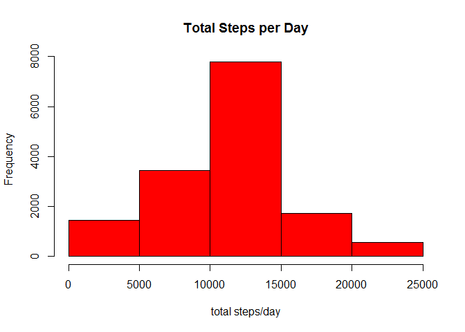

```r
hist(steps_per_day$total_steps, breaks=7,
     main = "Total Steps per Day",
     xlab = "total steps/day",
     col = "Red")
```

It looks normally distributed, with between 10,000 and 15,000 being the most most common count of total steps in a day.

The mean and median of the total steps per day can now be calculated.

```r
mean_total_steps <- as.integer(mean(steps_per_day$total_steps, na.rm=TRUE))
median_total_steps <- as.integer(median(steps_per_day$total_steps, na.rm=TRUE))
```

The mean of total steps per day is 10754. The median of total steps per day is 10682.

These are pretty close - another indication that total steps per day are normally distributed. Initially I would expect our participant to work a job that doesn’t require much differentially distributed travel (e.g. a 9-5).

## What is the average daily activity pattern?

The average daily activity pattern is more specifically obtained by taking the mean of each interval period over all the days. We can take a look at the plot of mean steps as a function of each interval period.

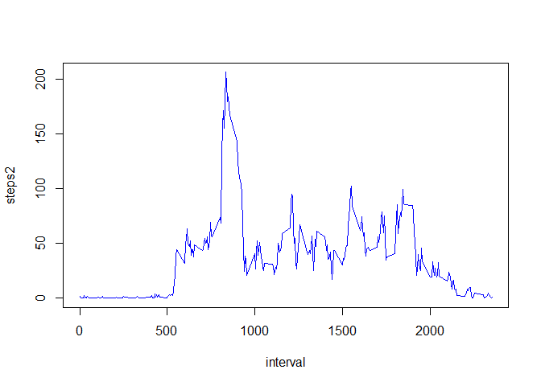

```r
steps_per_interval <- activity_data %>%
  tbl_df %>%
  group_by(interval) %>%
  summarize(steps2 = mean(steps, na.rm=TRUE))

par(mfrow =c(1,1))
with(steps_per_interval, plot(interval, steps2, type="l", col = "blue"))
```

And which interval contains the largest steps? We can compute this by indexing the max steps and using this index to obtain the interval.

```r
largest_interval <- which.max(steps_per_interval$steps2)
int <- steps_per_interval$interval[largest_interval]
int2 <- int+5
```

The interval containing the largest steps is 835 - 840.

## Imputing missing values

Many of the days have missing values. Possibly, some of the days are completely missing values, while some of the days may only have a few missing.

```r
dim_activity_data <- dim(activity_data)
how_many_na <- sum(is.na(activity_data$steps))

percentage_na <- how_many_na/dim_activity_data[1]
percentage_na <- percentage_na * 100
```

There are 2304 missing values which comprise 13.11% of the dataset.

One strategy for filling in these values would be to either: 1) Take the mean for the day and use this mean to fill in that days’ missing values. 1) If no values exist for a certain day, take the mean of all steps in the data set and use this value for that day.

I first create a data frame only containing the mean values for each day:

```r
activity_data_na <- activity_data #new df to have na values replaced.

##Na_replace is data frame of mean steps per day
na_replace <- activity_data_na %>%
  group_by(date) %>%
  summarize(steps_mean=mean(steps))
```

Then I create several placeholder integers/vectors to be used in the for loop.

```r
date_for_mean <- ymd("2012-10-01")
grab <- as.integer(0)
j <- as.integer(0)
```

The for/if/else construct determines the conditions sufficient for distinguishing the two situations outlined above - missing values within days and missing values for entire days.

```r
for (i in 1:length(activity_data_na$steps)) {
  all_means <- mean(na_replace$steps_mean, na.rm=TRUE) #find mean of all data
  date_for_mean <- ymd(activity_data_na[i,2])
  grab <- which(na_replace$date == ymd(date_for_mean))

    if (is.na(activity_data_na[i,1]) && # condition: data is NA
        !is.na(na_replace[date_for_mean,2])) { ##data is available

            activity_data_na[i,1] <- na_replace[grab,2]
    }

    else if (is.na(activity_data_na[i,1]) && #data is NA
             is.na(na_replace[date_for_mean,2])) { #data is not available

            activity_data_na[i,1] <- all_means
    }

    else if (!is.na(activity_data_na[i,1])) { #j tracks non-NA instances
       j <- j+1
    }

  i <- i+1
}
```

Now let’s compare the data with/without NA values replaced. First we calculate the total steps per day and compare histograms.

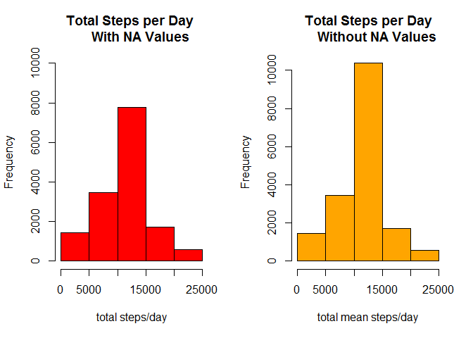

```r
steps_per_day_na <- activity_data_na %>%
  tbl_df %>%
  mutate(steps = as.numeric(as.character(steps))) %>%
  group_by(date) %>%
  mutate(total_steps = sum(steps))

par(mfrow=c(1,2))
##With NA Values
hist(steps_per_day$total_steps, breaks=7,
     ylim=c(1,10000),
     main = "Total Steps per Day
     With NA Values",
     xlab = "total steps/day",
     col="Red")

##Without NA Values
hist(steps_per_day_na$total_steps, breaks=7,
     main = "Total Steps per Day
     Without NA Values",
     xlab = "total mean steps/day",
     col ="Orange")
```

We can distinctly see that while the data appears to be normally distributed in both, replacing the missing values lead to higher counts of steps per day in the most frequent category, 10,000-15,000 steps per day.

Furthermore, we should look at a comparison between the mean and median of the data.

```r
##With NA Values
mean_total_steps <- mean(steps_per_day$total_steps, na.rm=TRUE)
median_total_steps <- median(steps_per_day$total_steps, na.rm=TRUE)
##Without NA Values
mean_total_steps_na <- mean(steps_per_day_na$total_steps, na.rm=TRUE)
median_total_steps_na <- median(steps_per_day_na$total_steps, na.rm=TRUE)
##Make a data frame
df <- data.frame(c(mean_total_steps, median_total_steps),
                c(mean_total_steps_na, median_total_steps_na))
row.names(df) <- c("With NA", "Without NA")
names(df) <- c("mean", "median")
print(df, type="html")
```

```
##             mean median
## With NA    10755  10766
## Without NA 10682  10766
```

## Are there differences in activity patterns between weekdays and weekends?

To find this, we need a new factor variable that keeps track of whether the day is a weekend or a weekday. I use a for/if/else construct to determine this per row. I also convert the column to a facor and name it.

```r
##FOR LOOPS FOR DAYS..>FEELING IT
for (i in 1:17568) {
ifelse(any(weekdays(activity_data_na$date[i]) ==
             c("Monday", "Tuesday","Wednesday","Thursday","Friday")),

       activity_data_na[i,4] <- "Weekday",
       activity_data_na[i,4] <- "Weekend")
}

activity_data_na[,4] <- as.factor(activity_data_na[,4])
names(activity_data_na) <- c("steps", "date", "interval", "Day")
```

Next is simply a matter of using the same program to average the steps per day per interval, and we also group by the type of day (labelled “Day”).

```r
steps_per_interval_na <- activity_data_na %>%
  tbl_df %>%
  group_by(interval, Day) %>%
  summarize(steps2 = mean(steps, na.rm=TRUE))
```

Let’s visualize the data.

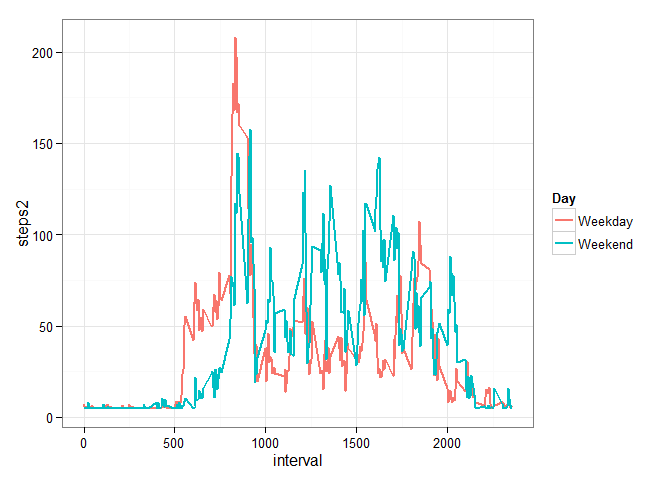

```r
p <- ggplot(steps_per_interval_na, aes(interval, steps2)) +
              geom_line(aes(colour = Day, Group = Day), size=.75) + theme_bw()
p + scale_fill_manual(values=c("#CC6666", "#9999CC"))
```

It appears that my initial expectation is confirmed to an extent with this data. Our subject has a spike in steps at the beginning of the day and at the end of the day, indicating perhaps walking to and from work. The weekend spikes are more distributed throughout the day.

Let’s view it again as a conditioning plot:

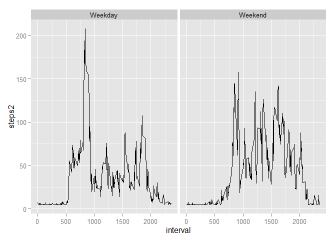

```r
p <- qplot(data=steps_per_interval_na, interval, steps2, facets=.~Day, geom="line")
p
```

Looks good!

## Limitations

There are limitations that need to be addressed in this analysis.

1. The number of intervals in the data are greater than the number of intervals in an actual day! We should look into the data set and creators to understand why this is going on.
2. I assumed that there may be missing values within a day, but I suspect that some days simply had missing values due to the participant not recording on those days. A linear regression could be used to better approximate what the missing values may have been.

## Citations

```r
citation("dplyr")
```

```
##
##
##   Hadley Wickham and Romain Francois (2015). dplyr: A Grammar of
##   Data Manipulation. R package version 0.4.3.
##   http://CRAN.R-project.org/package=dplyr
##
## A BibTeX entry for LaTeX users is
##
##   @Manual{,
##     title = {dplyr: A Grammar of Data Manipulation},
##     author = {Hadley Wickham and Romain Francois},
##     year = {2015},
##     note = {R package version 0.4.3},
##     url = {http://CRAN.R-project.org/package=dplyr},
##   }
```

```r
citation("ggplot2")
```

```
##
##
##   H. Wickham. ggplot2: elegant graphics for data analysis.
##   Springer New York, 2009.
##
## A BibTeX entry for LaTeX users is
##
##   @Book{,
##     author = {Hadley Wickham},
##     title = {ggplot2: elegant graphics for data analysis},
##     publisher = {Springer New York},
##     year = {2009},
##     isbn = {978-0-387-98140-6},
##     url = {http://had.co.nz/ggplot2/book},
##   }
```

```r
citation("lubridate")
```

```
##
##
##   Garrett Grolemund, Hadley Wickham (2011). Dates and Times Made
##   Easy with lubridate. Journal of Statistical Software, 40(3),
##   1-25. URL http://www.jstatsoft.org/v40/i03/.
##
## A BibTeX entry for LaTeX users is
##
##   @Article{,
##     title = {Dates and Times Made Easy with {lubridate}},
##     author = {Garrett Grolemund and Hadley Wickham},
##     journal = {Journal of Statistical Software},
##     year = {2011},
##     volume = {40},
##     number = {3},
##     pages = {1--25},
##     url = {http://www.jstatsoft.org/v40/i03/},
##   }
```

Peng, Roger D. 2013. Reproducible Research Peer Assessment 1. Coursera. https://class.coursera.org/repdata-035/human_grading/view/courses/975148/assessments/3/submissions/716